# Activity 07: XGBoost Quantile Forecast

Activity 07 tests XGBoost quantile-regression alternatives to the original ARIMA forecast. It keeps the same testing season, reference dates, horizons, target, location, and FluSight quantile ladder, but replaces `auto.arima()` with direct horizon-specific gradient-boosted trees.

Two XGBoost candidates are compared:

- Admissions-only XGBoost: lagged influenza admissions plus target-week seasonal harmonics.
- XGBoost + leading indicators: the same features plus NWSS WVAL and NSSP influenza ED visit signals lagged six weeks from the target week.

The leading indicators are lagged so that every feature is available before the forecast reference date.

```r
knitr::opts_chunk$set(message = FALSE, warning = TRUE, fig.width = 10, fig.height = 6)

find_project_dir <- function(start_dir = getwd()) {
  candidates <- unique(c(
    start_dir,
    file.path(start_dir, "USE-ME", "carolmoreira"),
    file.path(start_dir, ".."),
    file.path(start_dir, "..", ".."),
    file.path(start_dir, "..", "..", "..")
  ))
  candidates <- normalizePath(candidates, mustWork = FALSE)
  candidates <- candidates[file.exists(file.path(candidates, "output/scripts/07_xgboost_forecast.R"))]
  if (!length(candidates)) stop("Could not locate USE-ME/carolmoreira.")
  candidates[1]
}

project_dir <- find_project_dir()
knitr::opts_knit$set(root.dir = project_dir)
if (!isTRUE(getOption("knitr.in.progress"))) setwd(project_dir)
cat("Working directory:", project_dir, "\n")
```

```
## Working directory: /Users/carolmoreira/sismid/SISMID-2026-HumanAI/USE-ME/carolmoreira
```

## 1 Run The Workflow

The script below rebuilds the forecast, scores it, compares it with available benchmarks, and writes the figures used in this report.

```r
source("output/scripts/07_xgboost_forecast.R")
```

```
## Season Start Week: 2025-09-28
## Season End Week: 2026-05-17
##
## --- Rule 3 validations ---
## [val] Training Period start: 2020-08-08
## [val] Initial training window end (last pre-test week): 2025-09-27
## [val] Testing Period start: 2025-10-04
## [val] Forecast horizons: 1, 2, 3
## [val] Number of reference dates: 34
##
## --- Rule 1X validations (features) ---
## [val] feature names: lag1, lag2, lag3, lag4, sin1, cos1, sin2, cos2
## [val] leading feature names: lag1, lag2, lag3, lag4, sin1, cos1, sin2, cos2, wval_lag6, nssp_flu_lag6
## [val] XGBoost hyperparameters selected by pre-test rolling validation:
## # A tibble: 2 x 9
##   model          eta max_depth subsample colsample_bytree nrounds mean_wis   mae
##   <chr>        <dbl>     <int>     <dbl>            <dbl>   <int>    <dbl> <dbl>
## 1 XGBoost qua~  0.08         2       0.7              0.7     220     73.0  109.
## 2 XGBoost + l~  0.08         2       0.7              0.7     220    584.   746.
## # i 1 more variable: n_validation_forecasts <int>
##
## --- Rule 4X & 5X validations ---
## [val] XGBoost quantile ref 2025-09-27 | n_train(h1) = 265 | 23 quantiles OK | features no-NA OK | fit OK
## [val] XGBoost quantile ref 2025-10-04 | n_train(h1) = 266 | 23 quantiles OK | features no-NA OK | fit OK
## [val] XGBoost quantile ref 2025-10-11 | n_train(h1) = 267 | 23 quantiles OK | features no-NA OK | fit OK
## [val] XGBoost quantile ref 2025-10-18 | n_train(h1) = 268 | 23 quantiles OK | features no-NA OK | fit OK
## [val] XGBoost quantile ref 2025-10-25 | n_train(h1) = 269 | 23 quantiles OK | features no-NA OK | fit OK
## [val] XGBoost quantile ref 2025-11-01 | n_train(h1) = 270 | 23 quantiles OK | features no-NA OK | fit OK
## [val] XGBoost quantile ref 2025-11-08 | n_train(h1) = 271 | 23 quantiles OK | features no-NA OK | fit OK
## [val] XGBoost quantile ref 2025-11-15 | n_train(h1) = 272 | 23 quantiles OK | features no-NA OK | fit OK
## [val] XGBoost quantile ref 2025-11-22 | n_train(h1) = 273 | 23 quantiles OK | features no-NA OK | fit OK
## [val] XGBoost quantile ref 2025-11-29 | n_train(h1) = 274 | 23 quantiles OK | features no-NA OK | fit OK
## [val] XGBoost quantile ref 2025-12-06 | n_train(h1) = 275 | 23 quantiles OK | features no-NA OK | fit OK
## [val] XGBoost quantile ref 2025-12-13 | n_train(h1) = 276 | 23 quantiles OK | features no-NA OK | fit OK
## [val] XGBoost quantile ref 2025-12-20 | n_train(h1) = 277 | 23 quantiles OK | features no-NA OK | fit OK
## [val] XGBoost quantile ref 2025-12-27 | n_train(h1) = 278 | 23 quantiles OK | features no-NA OK | fit OK
## [val] XGBoost quantile ref 2026-01-03 | n_train(h1) = 279 | 23 quantiles OK | features no-NA OK | fit OK
## [val] XGBoost quantile ref 2026-01-10 | n_train(h1) = 280 | 23 quantiles OK | features no-NA OK | fit OK
## [val] XGBoost quantile ref 2026-01-17 | n_train(h1) = 281 | 23 quantiles OK | features no-NA OK | fit OK
## [val] XGBoost quantile ref 2026-01-24 | n_train(h1) = 282 | 23 quantiles OK | features no-NA OK | fit OK
```

[output cut: 46 more lines]

```
## [val] XGBoost + leading indicators ref 2026-04-25 | n_train(h1) = 88 | 23 quantiles OK | features no-NA OK | fit OK
## [val] XGBoost + leading indicators ref 2026-05-02 | n_train(h1) = 89 | 23 quantiles OK | features no-NA OK | fit OK
## [val] XGBoost + leading indicators ref 2026-05-09 | n_train(h1) = 90 | 23 quantiles OK | features no-NA OK | fit OK
## [val] XGBoost + leading indicators ref 2026-05-16 | n_train(h1) = 91 | 23 quantiles OK | features no-NA OK | fit OK
##
## --- Rule 5X output validations ---
## [val] quantiles non-decreasing: OK
## [val] all quantile levels present: OK
## [val] three horizons (one direct fit each): OK
## [val] target dates correct: OK
## [diag] intervals widen with horizon (h3>=h2>=h1): 19/34 reference dates (56%)
## [val] leading-indicator XGBoost FluSight output checks: OK
##
## Wrote 2346 rows to output/data/07_xgboost/xgboost_flusight_forecasts.csv ( 34 reference dates x 69 rows )
## Wrote 2346 rows to output/data/07_xgboost/xgboost_leading_flusight_forecasts.csv ( 34 reference dates x 69 rows )
```

```
##
## Activity 07 XGBoost complete.
## Forecast: output/data/07_xgboost/xgboost_flusight_forecasts.csv
## Leading-indicator forecast: output/data/07_xgboost/xgboost_leading_flusight_forecasts.csv
## Scores: output/data/07_xgboost/xgboost_forecast_scores.csv
## Comparison: output/data/07_xgboost/xgboost_model_comparison_by_horizon.csv
## # A tibble: 15 x 8
##    model     horizon n_forecasts   mae   rmse mean_wis coverage_95 mean_width_95
##    <chr>       <int>       <int> <dbl>  <dbl>    <dbl>       <dbl>         <dbl>
##  1 Activity~       1          34 1980.  3648.    1333.       0.941        10909.
##  2 Activity~       1          34 1859.  3446.    1494.       0.882         6244.
##  3 Original~       1          34 1954.  3405.    1547.       0.882         6257.
##  4 XGBoost ~       1          34 2605.  5092.    1650.       0.882        13476.
##  5 XGBoost ~       1          34 2600.  4919.    1763.       0.912        20658.
##  6 XGBoost ~       2          34 3374.  6723.    2297.       0.882        17240.
##  7 Activity~       2          34 3374.  6723.    2297.       0.882        17240.
##  8 XGBoost ~       2          34 5150.  8815.    3004.       0.941        24412.
##  9 Activity~       2          34 4365.  7732.    3485.       0.853        12061.
## 10 Original~       2          34 4408.  7926.    3532.       0.853        12097.
## 11 XGBoost ~       3          34 4024.  7366.    2667.       0.882        18210.
## 12 Activity~       3          34 4024.  7366.    2667.       0.882        18210.
## 13 XGBoost ~       3          34 6272. 10170.    3437.       0.941        29448.
## 14 Activity~       3          34 6072. 10940.    4837.       0.853        16627.
## 15 Original~       3          34 6102. 11356.    4914.       0.853        16683.
```

## 2 Load Outputs

```r
required <- c("readr", "dplyr", "tidyr", "ggplot2", "knitr")
missing <- required[!vapply(required, requireNamespace, logical(1), quietly = TRUE)]
if (length(missing)) stop("Required R package(s) not installed: ", paste(missing, collapse = ", "))

library(readr)
library(dplyr)
library(tidyr)
library(ggplot2)
library(knitr)
```

```r
forecast_csv <- "output/data/07_xgboost/xgboost_flusight_forecasts.csv"
leading_forecast_csv <- "output/data/07_xgboost/xgboost_leading_flusight_forecasts.csv"
scores_csv <- "output/data/07_xgboost/xgboost_forecast_scores.csv"
leading_scores_csv <- "output/data/07_xgboost/xgboost_leading_forecast_scores.csv"
summary_csv <- "output/data/07_xgboost/xgboost_summary_by_horizon.csv"
leading_summary_csv <- "output/data/07_xgboost/xgboost_leading_summary_by_horizon.csv"
comparison_csv <- "output/data/07_xgboost/xgboost_model_comparison_by_horizon.csv"
spec_csv <- "output/data/07_xgboost/xgboost_specification.csv"
diagnostics_csv <- "output/data/07_xgboost/xgboost_diagnostics.csv"
leading_diagnostics_csv <- "output/data/07_xgboost/xgboost_leading_diagnostics.csv"
tuning_csv <- "output/data/07_xgboost/xgboost_hyperparameter_tuning.csv"

forecast_png <- "output/figures/07_xgboost/xgboost_forecast_vs_observed.png"
leading_forecast_png <- "output/figures/07_xgboost/xgboost_leading_forecast_vs_observed.png"
comparison_png <- "output/figures/07_xgboost/xgboost_metric_comparison.png"
width_png <- "output/figures/07_xgboost/xgboost_interval_widths.png"
leading_width_png <- "output/figures/07_xgboost/xgboost_leading_interval_widths.png"
feature_png <- "output/figures/07_xgboost/xgboost_feature_overview.png"
leading_feature_png <- "output/figures/07_xgboost/xgboost_leading_feature_overview.png"
tuning_png <- "output/figures/07_xgboost/xgboost_hyperparameter_tuning.png"

expected <- c(forecast_csv, scores_csv, summary_csv, comparison_csv,
              spec_csv, diagnostics_csv, leading_forecast_csv,
              leading_scores_csv, leading_summary_csv, leading_diagnostics_csv,
              forecast_png, leading_forecast_png, comparison_png,
              width_png, leading_width_png, feature_png, leading_feature_png,
              tuning_csv, tuning_png)
if (!all(file.exists(expected))) {
  stop("Missing Activity 07 output(s): ", paste(expected[!file.exists(expected)], collapse = ", "))
}
```

## 3 Model Design

XGBoost has no built-in autoregressive time-series structure, so the weekly series is converted into a supervised learning table. For each reference date and horizon, both candidates use the last four known admissions values plus first and second seasonal harmonics for the target MMWR week. The leading candidate additionally uses WVAL and NSSP values from six weeks before the target week.

Hyperparameters are selected with a small rolling-validation grid using only pre-test reference dates. This avoids choosing XGBoost settings using the 2025-26 evaluation outcomes.

```r
read_csv(spec_csv, show_col_types = FALSE) %>%
  kable(caption = "XGBoost quantile model specification.")
```

XGBoost quantile model specification.

| model | response | external_regressors | features | framing | objective | quantile_levels | tuning_design | eta | max_depth | subsample | colsample_bytree | nrounds | seed |
| --- | --- | --- | --- | --- | --- | --- | --- | --- | --- | --- | --- | --- | --- |
| XGBoost quantile regression | weekly national influenza admissions | none | lag1; lag2; lag3; lag4; sin1; cos1; sin2; cos2 | direct per horizon; three models per reference date | reg:quantileerror | 0.01, 0.025, 0.05, 0.1, 0.15, 0.2, 0.25, 0.3, 0.35, 0.4, 0.45, 0.5, 0.55, 0.6, 0.65, 0.7, 0.75, 0.8, 0.85, 0.9, 0.95, 0.975, 0.99 | 8 pre-test rolling reference dates x 3 horizons | 0.08 | 2 | 0.7 | 0.7 | 220 | 42 |
| XGBoost quantile regression + leading indicators | weekly national influenza admissions | NWSS WVAL and NSSP influenza ED visits lagged six weeks from target week | lag1; lag2; lag3; lag4; sin1; cos1; sin2; cos2; wval_lag6; nssp_flu_lag6 | direct per horizon; three models per reference date | reg:quantileerror | 0.01, 0.025, 0.05, 0.1, 0.15, 0.2, 0.25, 0.3, 0.35, 0.4, 0.45, 0.5, 0.55, 0.6, 0.65, 0.7, 0.75, 0.8, 0.85, 0.9, 0.95, 0.975, 0.99 | 8 pre-test rolling reference dates x 3 horizons | 0.08 | 2 | 0.7 | 0.7 | 220 | 42 |

```r
read_csv(tuning_csv, show_col_types = FALSE) %>%
  mutate(across(c(mean_wis, mae), round, 3)) %>%
  arrange(model, mean_wis) %>%
  kable(caption = "Pre-test rolling-validation hyperparameter results.")
```

Pre-test rolling-validation hyperparameter results.

| model | eta | max_depth | subsample | colsample_bytree | nrounds | mean_wis | mae | n_validation_forecasts |
| --- | --- | --- | --- | --- | --- | --- | --- | --- |
| XGBoost + leading indicators | 0.08 | 2 | 0.7 | 0.7 | 220 | 583.972 | 746.375 | 24 |
| XGBoost + leading indicators | 0.03 | 2 | 0.8 | 0.8 | 220 | 609.169 | 645.125 | 24 |
| XGBoost + leading indicators | 0.05 | 3 | 0.8 | 0.8 | 300 | 834.812 | 1061.917 | 24 |
| XGBoost quantile | 0.08 | 2 | 0.7 | 0.7 | 220 | 73.045 | 108.750 | 24 |
| XGBoost quantile | 0.05 | 3 | 0.8 | 0.8 | 300 | 77.731 | 104.958 | 24 |
| XGBoost quantile | 0.03 | 2 | 0.8 | 0.8 | 220 | 83.577 | 110.292 | 24 |

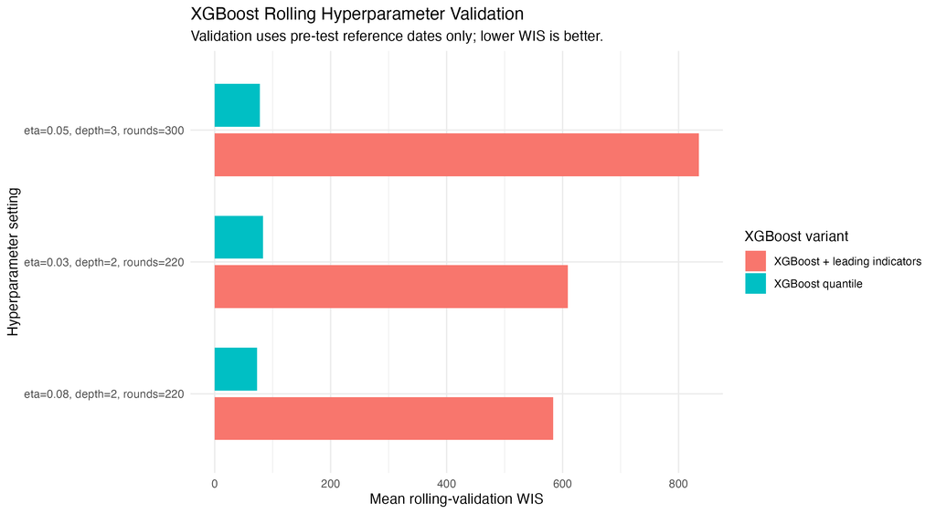

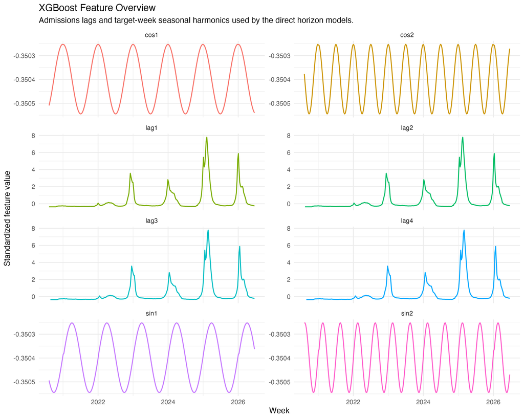

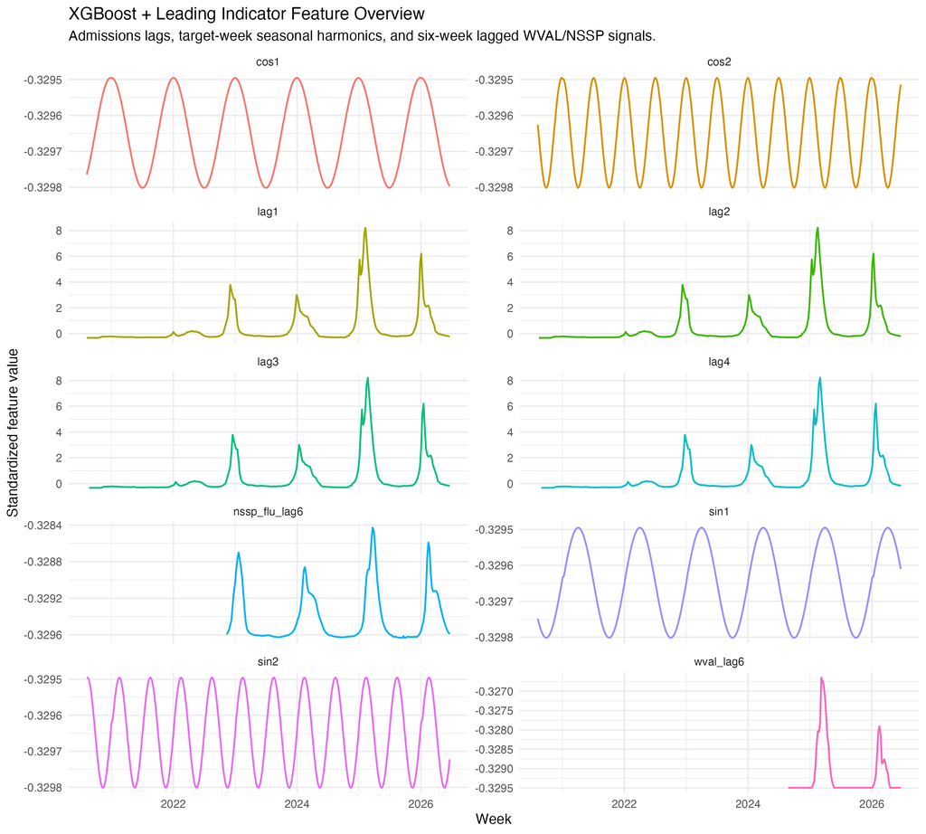

## 4 No-Look-Ahead Framing

The XGBoost model is fit directly by horizon. For a reference date `r` and horizon `h`, training examples use only anchor weeks whose observed target `t + 7h` is no later than `r`. Prediction uses the anchor week `r`, so all lag features are known at forecast time.

```r
diagnostics <- read_csv(diagnostics_csv, show_col_types = FALSE)
leading_diagnostics <- read_csv(leading_diagnostics_csv, show_col_types = FALSE)
bind_rows(diagnostics, leading_diagnostics) %>%
  group_by(horizon) %>%
  summarise(
    models = n_distinct(model),
    reference_dates = n_distinct(reference_date),
    min_training_rows = min(n_training_rows),
    max_training_rows = max(n_training_rows),
    .groups = "drop"
  ) %>%
  kable(caption = "Training row counts by direct forecast horizon.")
```

Training row counts by direct forecast horizon.

| horizon | models | reference_dates | min_training_rows | max_training_rows |
| --- | --- | --- | --- | --- |
| 1 | 2 | 34 | 58 | 298 |
| 2 | 2 | 34 | 58 | 297 |
| 3 | 2 | 34 | 58 | 296 |

## 5 FluSight Forecast Output

Each reference date emits 69 rows: 3 horizons times 23 quantiles. Quantiles are clamped at zero, rounded to integer counts, sorted to prevent crossing, and validated against the FluSight date and ladder rules.

```r
forecasts <- read_csv(forecast_csv, show_col_types = FALSE)
forecasts %>%
  arrange(reference_date, horizon, output_type_id) %>%
  head(12) %>%
  kable(caption = "Preview of the Activity 07 FluSight-format XGBoost forecast.")
```

Preview of the Activity 07 FluSight-format XGBoost forecast.

| reference_date | target | horizon | target_end_date | location | output_type | output_type_id | value |
| --- | --- | --- | --- | --- | --- | --- | --- |
| 2025-09-27 | wk inc flu hosp | 1 | 2025-10-04 | US | quantile | 0.010 | 328 |
| 2025-09-27 | wk inc flu hosp | 1 | 2025-10-04 | US | quantile | 0.025 | 693 |
| 2025-09-27 | wk inc flu hosp | 1 | 2025-10-04 | US | quantile | 0.050 | 879 |
| 2025-09-27 | wk inc flu hosp | 1 | 2025-10-04 | US | quantile | 0.100 | 920 |
| 2025-09-27 | wk inc flu hosp | 1 | 2025-10-04 | US | quantile | 0.150 | 1039 |
| 2025-09-27 | wk inc flu hosp | 1 | 2025-10-04 | US | quantile | 0.200 | 1072 |
| 2025-09-27 | wk inc flu hosp | 1 | 2025-10-04 | US | quantile | 0.250 | 1087 |
| 2025-09-27 | wk inc flu hosp | 1 | 2025-10-04 | US | quantile | 0.300 | 1118 |
| 2025-09-27 | wk inc flu hosp | 1 | 2025-10-04 | US | quantile | 0.350 | 1118 |
| 2025-09-27 | wk inc flu hosp | 1 | 2025-10-04 | US | quantile | 0.400 | 1125 |
| 2025-09-27 | wk inc flu hosp | 1 | 2025-10-04 | US | quantile | 0.450 | 1132 |
| 2025-09-27 | wk inc flu hosp | 1 | 2025-10-04 | US | quantile | 0.500 | 1171 |

```r
leading_forecasts <- read_csv(leading_forecast_csv, show_col_types = FALSE)
leading_forecasts %>%
  arrange(reference_date, horizon, output_type_id) %>%
  head(12) %>%
  kable(caption = "Preview of the Activity 07 XGBoost + leading indicators forecast.")
```

Preview of the Activity 07 XGBoost + leading indicators forecast.

| reference_date | target | horizon | target_end_date | location | output_type | output_type_id | value |
| --- | --- | --- | --- | --- | --- | --- | --- |
| 2025-09-27 | wk inc flu hosp | 1 | 2025-10-04 | US | quantile | 0.010 | 454 |
| 2025-09-27 | wk inc flu hosp | 1 | 2025-10-04 | US | quantile | 0.025 | 635 |
| 2025-09-27 | wk inc flu hosp | 1 | 2025-10-04 | US | quantile | 0.050 | 718 |
| 2025-09-27 | wk inc flu hosp | 1 | 2025-10-04 | US | quantile | 0.100 | 766 |
| 2025-09-27 | wk inc flu hosp | 1 | 2025-10-04 | US | quantile | 0.150 | 782 |
| 2025-09-27 | wk inc flu hosp | 1 | 2025-10-04 | US | quantile | 0.200 | 860 |
| 2025-09-27 | wk inc flu hosp | 1 | 2025-10-04 | US | quantile | 0.250 | 872 |
| 2025-09-27 | wk inc flu hosp | 1 | 2025-10-04 | US | quantile | 0.300 | 887 |
| 2025-09-27 | wk inc flu hosp | 1 | 2025-10-04 | US | quantile | 0.350 | 903 |
| 2025-09-27 | wk inc flu hosp | 1 | 2025-10-04 | US | quantile | 0.400 | 920 |
| 2025-09-27 | wk inc flu hosp | 1 | 2025-10-04 | US | quantile | 0.450 | 943 |
| 2025-09-27 | wk inc flu hosp | 1 | 2025-10-04 | US | quantile | 0.500 | 987 |

[figure not shown]

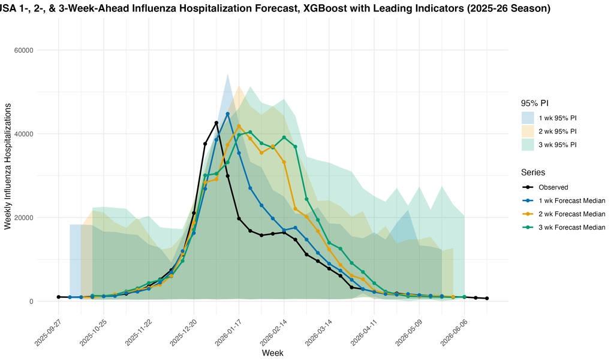

## 6 XGBoost Performance

```r
xgb_summary <- read_csv(summary_csv, show_col_types = FALSE)
xgb_leading_summary <- read_csv(leading_summary_csv, show_col_types = FALSE)
bind_rows(xgb_summary, xgb_leading_summary) %>%
  mutate(across(c(mae, rmse, mean_wis, coverage_95, mean_width_95), round, 3)) %>%
  arrange(horizon, mean_wis) %>%
  kable(caption = "XGBoost forecast performance by horizon.")
```

XGBoost forecast performance by horizon.

| model | horizon | n_forecasts | mae | rmse | mean_wis | coverage_95 | mean_width_95 |
| --- | --- | --- | --- | --- | --- | --- | --- |
| XGBoost quantile | 1 | 34 | 2604.941 | 5092.188 | 1649.641 | 0.882 | 13476.44 |
| XGBoost + leading indicators | 1 | 34 | 2599.735 | 4918.741 | 1762.556 | 0.912 | 20657.68 |
| XGBoost quantile | 2 | 34 | 3374.029 | 6723.131 | 2296.544 | 0.882 | 17240.38 |
| XGBoost + leading indicators | 2 | 34 | 5149.941 | 8815.174 | 3004.309 | 0.941 | 24411.76 |
| XGBoost quantile | 3 | 34 | 4024.294 | 7365.864 | 2666.561 | 0.882 | 18209.88 |
| XGBoost + leading indicators | 3 | 34 | 6272.265 | 10170.137 | 3437.227 | 0.941 | 29447.82 |

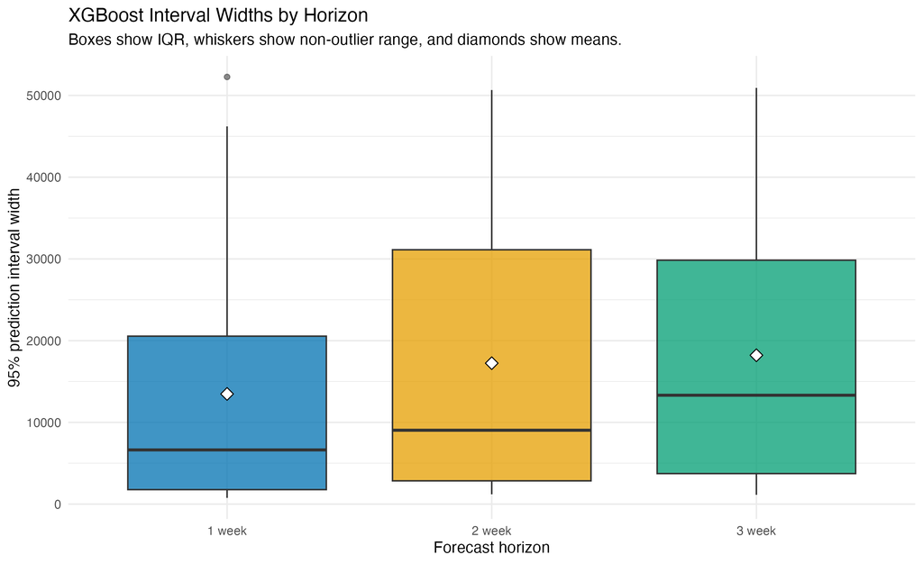

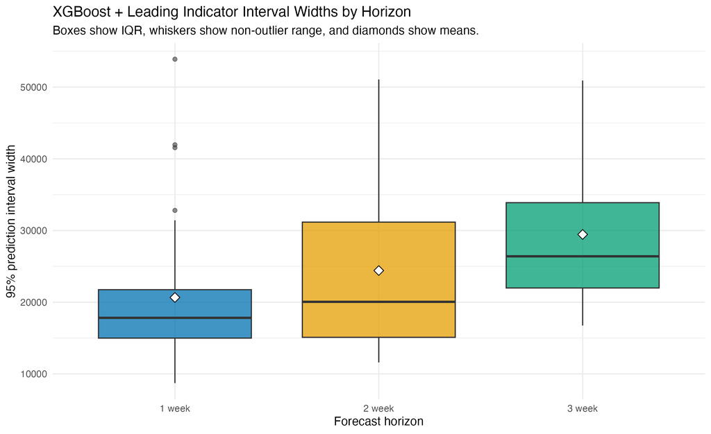

## 7 Comparison With Other Versions

The comparison table includes both XGBoost candidates plus the original ARIMA baseline, Activity 5 ensemble, and Activity 8 final forecast when those outputs are available locally. In this run, adding leading indicators improved coverage but widened intervals enough to worsen WIS relative to admissions-only XGBoost.

```r
comparison <- read_csv(comparison_csv, show_col_types = FALSE)
comparison %>%
  mutate(across(c(mae, rmse, mean_wis, coverage_95, mean_width_95), round, 3)) %>%
  arrange(horizon, mean_wis) %>%
  kable(caption = "Activity 07 XGBoost compared with available forecast versions.")
```

Activity 07 XGBoost compared with available forecast versions.

| model | horizon | n_forecasts | mae | rmse | mean_wis | coverage_95 | mean_width_95 |
| --- | --- | --- | --- | --- | --- | --- | --- |
| Activity 8 current final | 1 | 34 | 1980.235 | 3648.463 | 1333.178 | 0.941 | 10908.618 |
| Activity 5 ensemble | 1 | 34 | 1859.176 | 3446.426 | 1494.176 | 0.882 | 6243.500 |
| Original ARIMA | 1 | 34 | 1954.176 | 3404.723 | 1547.448 | 0.882 | 6257.294 |
| XGBoost quantile | 1 | 34 | 2604.941 | 5092.188 | 1649.641 | 0.882 | 13476.441 |
| XGBoost + leading indicators | 1 | 34 | 2599.735 | 4918.741 | 1762.556 | 0.912 | 20657.676 |
| XGBoost quantile | 2 | 34 | 3374.029 | 6723.131 | 2296.544 | 0.882 | 17240.382 |
| Activity 8 current final | 2 | 34 | 3374.029 | 6723.131 | 2296.544 | 0.882 | 17240.382 |
| XGBoost + leading indicators | 2 | 34 | 5149.941 | 8815.174 | 3004.309 | 0.941 | 24411.765 |
| Activity 5 ensemble | 2 | 34 | 4364.676 | 7732.303 | 3484.610 | 0.853 | 12060.765 |
| Original ARIMA | 2 | 34 | 4407.706 | 7925.581 | 3531.953 | 0.853 | 12096.559 |
| XGBoost quantile | 3 | 34 | 4024.294 | 7365.864 | 2666.561 | 0.882 | 18209.882 |
| Activity 8 current final | 3 | 34 | 4024.294 | 7365.864 | 2666.561 | 0.882 | 18209.882 |
| XGBoost + leading indicators | 3 | 34 | 6272.265 | 10170.137 | 3437.227 | 0.941 | 29447.824 |
| Activity 5 ensemble | 3 | 34 | 6071.824 | 10939.742 | 4837.259 | 0.853 | 16627.265 |
| Original ARIMA | 3 | 34 | 6102.235 | 11355.899 | 4914.413 | 0.853 | 16682.618 |

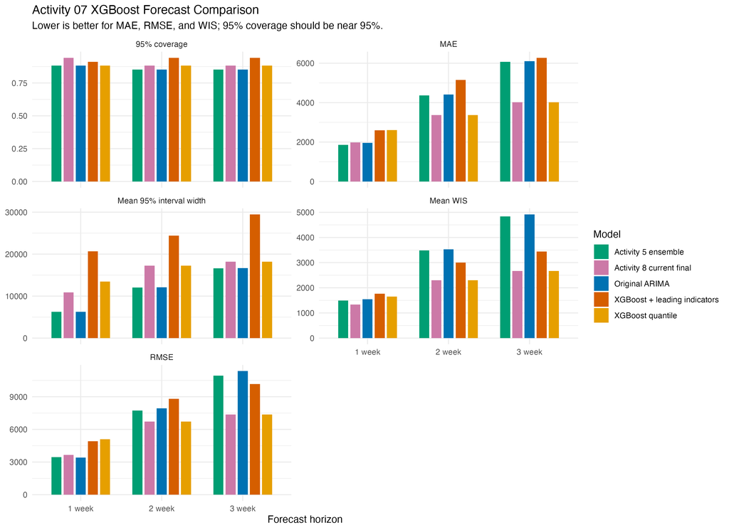

## 8 Interpretation

XGBoost behaves differently from ARIMA-style models. It can learn nonlinear relationships between recent admissions, season timing, and future admissions, which helps at longer horizons here. Adding WVAL/NSSP did not improve WIS in this backtest, likely because the surveillance streams have a shorter aligned history and produced much wider intervals. This is still useful evidence: the leading signal is available, but it needs more careful regularization or a targeted ensemble before it should replace admissions-only XGBoost.

After tuning, the selected settings are more regularized than the original fixed default: shallower trees with column and row subsampling. That improves the rigor of the comparison even when the final winner remains a horizon-level ensemble in Activity 08.

```r
tibble::tribble(
  ~aspect, ~assessment,
  "Strength",
  "Strong two- and three-week WIS in this evaluation window.",
  "Strength",
  "Uses the exact same FluSight format and reference dates as the baseline.",
  "Strength",
  "Direct quantile regression allows asymmetric predictive distributions.",
  "Strength",
  "A leakage-safe WVAL/NSSP XGBoost variant is now tested directly.",
  "Weakness",
  "The leading-indicator variant widened intervals and worsened WIS in this run.",
  "Weakness",
  "Less interpretable than ARIMA or ARIMAX.",
  "Weakness",
  "Direct horizon models do not always produce intervals that widen monotonically."
) %>%
  kable(caption = "Summary of Activity 07 strengths and weaknesses.")
```

Summary of Activity 07 strengths and weaknesses.

| aspect | assessment |
| --- | --- |
| Strength | Strong two- and three-week WIS in this evaluation window. |
| Strength | Uses the exact same FluSight format and reference dates as the baseline. |
| Strength | Direct quantile regression allows asymmetric predictive distributions. |
| Strength | A leakage-safe WVAL/NSSP XGBoost variant is now tested directly. |
| Weakness | The leading-indicator variant widened intervals and worsened WIS in this run. |
| Weakness | Less interpretable than ARIMA or ARIMAX. |
| Weakness | Direct horizon models do not always produce intervals that widen monotonically. |

## 9 Reproducibility Summary

```r
cat("Forecast CSV:", forecast_csv, "\n")
```

```
## Forecast CSV: output/data/07_xgboost/xgboost_flusight_forecasts.csv
```

```r
cat("Leading forecast CSV:", leading_forecast_csv, "\n")
```

```
## Leading forecast CSV: output/data/07_xgboost/xgboost_leading_flusight_forecasts.csv
```

```r
cat("Scores CSV:", scores_csv, "\n")
```

```
## Scores CSV: output/data/07_xgboost/xgboost_forecast_scores.csv
```

```r
cat("Leading scores CSV:", leading_scores_csv, "\n")
```

```
## Leading scores CSV: output/data/07_xgboost/xgboost_leading_forecast_scores.csv
```

```r
cat("Comparison CSV:", comparison_csv, "\n")
```

```
## Comparison CSV: output/data/07_xgboost/xgboost_model_comparison_by_horizon.csv
```

```r
cat("Rows in forecast:", nrow(forecasts), "\n")
```

```
## Rows in forecast: 2346
```

```r
cat("Rows in leading forecast:", nrow(leading_forecasts), "\n")
```

```
## Rows in leading forecast: 2346
```

```r
cat("Reference dates:", dplyr::n_distinct(forecasts$reference_date), "\n")
```

```
## Reference dates: 34
```

```r
cat("Rows per reference date:", nrow(forecasts) / dplyr::n_distinct(forecasts$reference_date), "\n")
```

```
## Rows per reference date: 69
```